# 4Diffrakcio slides

Miller-indexek és kristálysíkok online: http://calistry.org/calculate/latticePlanesMillerIndices

Krisztallográfiás konverziók és azok magyarázata: http://ssd.phys.strath.ac.uk/resources/crystallography/crystallographic-direction-calculator/

A Wolfram kristálynézegető online oldala: https://demonstrations.wolfram.com/CrystalViewer/

https://www.nobelprize.org/prizes/chemistry/2011/shechtman/lecture/

[figure not shown]

## Röntgen diffrakció

- rugalmas szórás -> nincs energia transzfer $$|k_i|=|k_o|=\frac{2\pi}{\lambda}$$

[figure not shown]

### A két nyaláb útkülönbsége

$ \mul{r}\cos\alpha = -\mul{r}\frac{\mul{k}_i}{|k_i|} \enspace \mul{r}\cos\beta = \mul{r}\frac{\mul{k}_o}{|k_o|}$

$$\Delta s = \mul{r}\left(\frac{\mul{k}_o}{|\mul{k}_o|}-\frac{\mul{k}_i}{|\mul{k}_i|}\right)= \frac{\mul{r}}\lambda{2\pi}(\mul{k}_o-\mul{k}_i)$$

### és a fáziskülönbség

$$\Delta \phi=\frac{\Delta s}{\lambda}2\pi=\mathbf{\underline{r}}\underbrace{(\mathbf{\underline{k}_o}-\mathbf{\underline{k}_i})}_\mathbf{\underline{\kappa}} = \mathbf{\underline{r}}\mathbf{\underline{\kappa}}$$

### Amplitúdó adott szögben

A diffrakciós képen adott szögben a következőképpen kapjuk meg az intenzitást:

Az egész kristály térfogára integrálunk az alábbi kifejezésben $$A(\kappa)=\int \rho(\mul{r})\exp^{i\Delta\phi(\mul{r})}\mathrm{d}\mathrm{V}=\int \rho(\mul{r})\exp^{i\kappa\mul{r}}\mathrm{d}\mathrm{r}^3$$ $$I(\kappa)=|A(\kappa)|^2$$ Itt $\rho(r)$ a szóró közeget leíró mennyiség (röntgen esetén elektronok például), $\exp^{i\Delta\phi(\mul{r})}$ adja meg interferencia mértékét a különböző pontokról szóródó nyalábokra.

### Rácsperiódikus esetben

Átírjuk úgy az előző kifejezést, úgy hogy az integrál már csak az elemi cella térfogatára történjen és azon belül is a bázis atomjaira külön-külön. Majd ezeket összegezzük $\sum_{p}$ illetve összegzünk az összes elemi cellára is $\sum_{\underline{R}_n}$

[figure not shown]

$$A(\kappa)=\underbrace{\sum_{\mul{R}_n} \exp^{i\mul{\kappa}\mul{R}_n}}_\text{Bragg-tényező}\underbrace{\sum_p \exp^{i\mul{\kappa}\mul{r}_p}}_\text{ Szerkezeti tényező}\underbrace{\int \rho(\mul{r}')\exp^{i\mul{\kappa}\mul{r}'}\mathrm{d}\mathrm{r'}^3}_\text{atomi szórási tényező}$$

### Rácsperiódikus esetben

$$A(\kappa)=\underbrace{\sum_{\mul{R}_n} \exp^{i\mul{\kappa}\mul{R}_n} }_\text{Bragg-tényező}\underbrace{\sum_p \exp^{i\mul{\kappa}\mul{r}_p}}_\text{ Szerkezeti tényező}\underbrace{\int \rho(\mathbf{\underline{r}'})\exp^{i\mul{\kappa}\mul{r}'}\mathrm{d}\mathrm{r'}^3}_{\text{atomi szórási tényező, } f(\mul{\kappa})}$$

$\sigma(\mul{\kappa}) = \sum_{\mul{R}_n} \exp^{i\mul{\kappa}\mul{R}_n}$

$$A(\mul{\kappa}) = \sigma(\mul{\kappa})\sum_p \exp^{i\mul{\kappa}\mul{r}_p}f(\mathbf{\underline{\kappa}})=\sigma(\mul{\kappa})S(\mul{\kappa})$$

## Bragg tényező

$$\underbrace{\sum_\mathbf{\underline{R}_n} \exp^{i\mathbf{\underline{\kappa}}\mathbf{\underline{R}_n}} }_\text{Bragg-tényező}$$

```python
interactive(ploteikr,i=widgets.IntSlider(min=0,max=30,step=1,value=0))
```

## Hol várható a legnagyobb erősítés?

$\exp^{i\mul{\kappa}\mul{R}_n} = 1$ lesz minden $\mul{R}_n$ rácsvektor értékre $$\mul{\kappa}\mul{R}_n=2\pi(\underbrace{n_1h + n_2k+n_3l}_\text{egész számot kell adniuk})$$ $$\mul{\kappa} = 2\pi (h\mul{b}_1 + k\mul{b}_2 + l\mul{b}_3)= \mul{g}_{hkl}$$

## Atomi szórási tényező, form faktor

(BME jegyzet 3.2) $$f(\mathbf{\underline{\kappa}}) = \int \rho(\mathbf{\underline{r}})\exp^{i\mathbf{\underline{\kappa}}\mathbf{\underline{r}}}\mathrm{d}\mathrm{r}^3=\frac{4\pi}{\mathbf{\underline{\kappa}}}\int_0^\infty\mathrm{dr}\mathbf{\underline{r}}\rho(\mathbf{\underline{r}})\sin(\mathbf{\underline{\kappa}}\mathbf{\underline{r}})$$

### Atomi szórási tényező 1s pályák esetén

(BME jegyzet 3.2.1) $$f_{1s}(\mathbf{\underline{\kappa}})=\frac{q}{\left[ 1+ \left(\frac{\mathbf{\underline{\kappa}}a_{B}}{2}\right)^2 \right]^2}$$

$$f_{1s}(\mathbf{\underline{\kappa}})=\frac{q}{\left[ 1+ \left(\frac{\mathbf{\underline{\kappa}}a_{B}}{2}\right)^2 \right]}$$

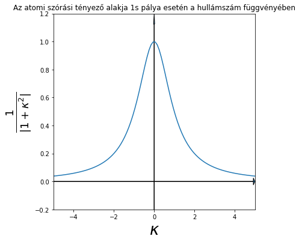

```python
plotfk()
```

### Számoljuk ki a diffrakciós csúcsok relatív intenzitását

[figure not shown]

$$A(\kappa)=\sigma(\mathbf{\underline{\kappa}})S(\mathbf{\underline{\kappa}})=\underbrace{\sum_\mathbf{\underline{R}_n} \exp^{i\mathbf{\underline{\kappa}}\mathbf{\underline{R}_n}} }_\text{Bragg-tényező}\underbrace{\sum_p \exp^{i\mathbf{\underline{\kappa}}\mathbf{\underline{r}_p}}f(\mathbf{\underline{\kappa}})}_\text{ Szerkezeti tényező}$$

Mivel a Bragg-tényezőről tudjuk, hogy csak egész h,k és l értékek esetén ad járulékot ezért már csak a szerkezeti tényezőt kell kiszámolni. $\sum_p \exp^{i\mathbf{\underline{\kappa}}\mathbf{\underline{r}_p}}f(\mathbf{\underline{\kappa}})$

Azonos atomokról van szó, ezért $f(\mathbf{\underline{\kappa}})$-t vegyük 1-nek

$$\sum_p \exp^{i\mul{\kappa}\mul{r}_p}f(\mul{\kappa})$$

**Laue feltétel** miatt:

$\kappa = \mul{k}_o - \mul{k}_i = \mul{g}_{hkl} = h\mul{b}_1 + k\mul{b}_2 + l\mul{b}_3=\frac{2\pi}{a} (h\mul{e}_x + k\mul{e}_y + l\mul{e}_z) $

**Atomi bázisok** koordinátái:

$\mul{r}_1=(0,0,0) \hphantom{rrr} \mul{r}_1=\frac{a}{2}(0,\mul{e}_y,0) \hphantom{rrr} \mul{r}_1=\frac{a}{2}(0,0,\mul{e}_z)$

$S(\mul{\kappa}) = 1 + \exp^{i\pi k} + \exp^{i\pi l}$

### SC esetén

$$d_{hkl}=\frac{a}{\sqrt{h^2 + k^2 + l^2}}$$

$N=h^2+k^2+l^2$

$$\sin\theta =\frac{\lambda\sqrt{N}}{2a}$$

$S(\mul{\kappa}) = 1 + \exp^{i\pi k} + \exp^{i\pi l}$

- h értéke teljesen mindegy, mivel nem szerepel $S(\mul{\kappa})$-ban
- $N=h^2+k^2+l^2$
- $|S_r|^r$ = a relatív intenzitás

| N | k | l | $S$ | $S_r$ |
| --- | --- | --- | --- | --- |
| 0 | 0 | 0 | 9 | 1 |
| 1 | 1 | 0 | 1 | $\frac{1}{9}$ |
| 1 | 0 | 1 | 1 | $\frac{1}{9}$ |
| 2 | 1 | 1 | 1 | $\frac{1}{9}$ |
| 5 | 2 | 1 | 1 | $\frac{1}{9}$ |
| 5 | 1 | 2 | 1 | $\frac{1}{9}$ |
| 8 | 2 | 2 | 9 | 1 |

A $h,k,l=0$ eset nem érdekes, mivel a nullad rendű nyaláb sokkal intenzívebb